# NZ GREEN Grid Household Electricity Demand Data

EECA Data Analysis (Part B) Report v2.2

Dortans, C., Anderson, B. and Jack, M.

Last run at: 2022-04-28 14:41:18 (Europe/London)

**Abstract**

This report uses the GREEN Grid project research data to analyse a variety of residential household appliances and their contribution to peak demand under several scenarios. Although the data does not derive from a representative sample of households, we demonstrate that identifiable heating contributes ~ 21% to residential peak (17:00-21:00) demand in winter with Hot Water at ~ 17%, Lighting at 14% and Ovens at 7% while non-identified appliances contribute ~ 40%. These percentage contributions are generally similar at both regional network and sample co-incident peaks and across seasons although total power demand varies by season according to the appliance. Thus ‘Others,’ heating and lighting are substantially lower in summer and whilst further research is clearly needed to unpack ‘Other’ demand, this suggests heating may be a major component.

Our results also show that simple mean (or median) values or single indicators such as average load factors mask considerable variation both within and between households. Overall we conclude that future work should focus on collecting data from a larger and representative sample of New Zealand households, ensuring that appliances are identified on circuits (especially electric heaters) and that both inter and intra-household heterogeneity should be adequately represented in analytic results.

# 1 About

## 1.1 Citation

If you wish to use any of the material from this report please cite as:

- Dortans, C., Anderson, B. and Jack, M. (2022) *NZ GREEN Grid Household Electricity Demand Data: EECA Data Analysis (Part B) Report v2.2*, [Centre for Sustainability](http://www.otago.ac.nz/centre-sustainability/), University of Otago: Dunedin.

This work is (c) 2022 the authors. Usage rights are specified in the License section (1.3).

## 1.2 Report circulation:

- Public – this report is intended for publication following EECA approval.

## 1.3 License

This work is made available under the Creative Commons [Attribution-ShareAlike 4.0 International (CC BY-SA 4.0) License](https://creativecommons.org/licenses/by-sa/4.0/).

This means you are free to:

- *Share* — copy and redistribute the material in any medium or format
- *Adapt* — remix, transform, and build upon the material for any purpose, even commercially.

Under the following terms:

- *Attribution* — You must give appropriate credit, provide a link to the license, and indicate if changes were made. You may do so in any reasonable manner, but not in any way that suggests the licensor endorses you or your use.
- *ShareAlike* — If you remix, transform, or build upon the material, you must distribute your contributions under the same license as the original.
- *No additional restrictions* — You may not apply legal terms or technological measures that legally restrict others from doing anything the license permits.

**Notices:**

- You do not have to comply with the license for elements of the material in the public domain or where your use is permitted by an applicable exception or limitation.
- No warranties are given. The license may not give you all of the permissions necessary for your intended use. For example, other rights such as publicity, privacy, or moral rights may limit how you use the material.

For the avoidance of doubt and explanation of terms please refer to the full [license notice](https://creativecommons.org/licenses/by-sa/4.0/) and [legal code](https://creativecommons.org/licenses/by-sa/4.0/legalcode).

## 1.4 History

You may not be reading the most recent version of this report. Please check:

- the github [R code repository](https://cfsotago.github.io/GREENGridEECA/);
- our [issues list](https://github.com/CfSOtago/GREENGridEECA/issues) for any unfixed problems;
- our [project documentation site](https://cfsotago.github.io/GREENGridEECA/) and specifically;
- this [report’s edit history](https://github.com/CfSOtago/GREENGridEECA/commits/master/reports/partB_dataAnalysis)

## 1.5 Support

This work was supported by:

- The New Zealand Energy Efficiency and Conservation Authority ([EECA](https://www.eeca.govt.nz/))

# 2 Introduction

This report uses the GREEN Grid project (Stephenson et al. 2017) research data to analyse a variety of residential household appliances and their contribution to peak demand under several scenarios.

# 3 Data

- 1 minute electricity power (W) data was collected for each dwelling circuit using [GridSpy](https://gridspy.com/) monitors on each power circuit (and the incoming power). The power values represent mean(W) over the minute preceding the observation timestamp;
- Dwelling & appliance surveys;
- Occupant time-use diaries (focused on energy use).

The data collection was supported by the New Zealand [Ministry of Business, Innovation and Employment (MBIE)](http://www.mbie.govt.nz/) through the [Renewable Energy and the Smart Grid (GREEN Grid)](https://www.otago.ac.nz/centre-sustainability/research/energy/otago050285.html) grant (Contract ID: UOCX1203).

As background, Table 3.1 shows the mean half-hourly and mean total kW and kWh by season for the sample households in 2015. For this purpose the periods are defined as:

- 21:00 - 07:00 Off peak (night)
- 07:00 - 09:00 Peak (morning)
- 09:00 - 17:00 Off peak (day)
- 17:00 - 21:00 Peak (evening)

Note that the mean kWh values are substantially different from the medians indicating a skewed distribution.

Table 3.1: Descriptive statistics for power data (overall household total demand/energy use)

| Season | Peak | N households | Mean half-hourly kW | s.d. (half-hourly kW) | Mean half-hourly kWh | Median half-hourly kWh | Mean total kWh for the period |
| --- | --- | --- | --- | --- | --- | --- | --- |
| Autumn | Off peak (day) | 34 | 0.90 | 0.93 | 0.45 | 0.26 | 5.80 |
| Autumn | Off peak (night) | 34 | 0.68 | 0.75 | 0.34 | 0.20 | 5.68 |
| Autumn | Peak (evening) | 34 | 1.56 | 1.27 | 0.78 | 0.60 | 5.21 |
| Autumn | Peak (morning) | 34 | 1.39 | 1.34 | 0.69 | 0.45 | 2.28 |
| Spring | Off peak (day) | 27 | 0.88 | 0.91 | 0.44 | 0.26 | 6.40 |
| Spring | Off peak (night) | 27 | 0.73 | 0.82 | 0.37 | 0.20 | 6.87 |
| Spring | Peak (evening) | 27 | 1.54 | 1.28 | 0.77 | 0.59 | 5.76 |
| Spring | Peak (morning) | 27 | 1.39 | 1.31 | 0.70 | 0.47 | 2.57 |
| Summer | Off peak (day) | 32 | 0.74 | 0.74 | 0.37 | 0.23 | 3.50 |
| Summer | Off peak (night) | 32 | 0.53 | 0.54 | 0.27 | 0.18 | 3.29 |
| Summer | Peak (evening) | 32 | 1.01 | 0.88 | 0.51 | 0.36 | 2.45 |
| Summer | Peak (morning) | 32 | 0.95 | 0.98 | 0.48 | 0.29 | 1.14 |
| Winter | Off peak (day) | 31 | 1.13 | 1.12 | 0.57 | 0.35 | 7.82 |
| Winter | Off peak (night) | 31 | 0.94 | 0.99 | 0.47 | 0.26 | 8.38 |
| Winter | Peak (evening) | 31 | 2.22 | 1.52 | 1.11 | 0.98 | 7.87 |
| Winter | Peak (morning) | 31 | 1.79 | 1.60 | 0.90 | 0.67 | 3.16 |

The following table estimates the mean total kWh per period using a different method (i.e. directly from the half-hourly level data) as a cross-check.

Table 3.2: Mean household total kWh per period and season (alternative method)

| season | ba_peak | mean_SumkWh |
| --- | --- | --- |
| Autumn | Off peak (day) | 6.76 |
| Autumn | Off peak (night) | 6.69 |
| Autumn | Peak (evening) | 6.09 |
| Autumn | Peak (morning) | 2.72 |
| Spring | Off peak (day) | 6.93 |
| Spring | Off peak (night) | 7.40 |
| Spring | Peak (evening) | 6.24 |
| Spring | Peak (morning) | 2.77 |
| Summer | Off peak (day) | 5.70 |
| Summer | Off peak (night) | 5.37 |
| Summer | Peak (evening) | 4.05 |
| Summer | Peak (morning) | 2.04 |
| Winter | Off peak (day) | 8.74 |
| Winter | Off peak (night) | 9.33 |
| Winter | Peak (evening) | 8.84 |
| Winter | Peak (morning) | 3.60 |

Figure 3.1 shows the mean total kWh consumed per household by period and season. Note that this total reflects not only the power demand level but the number of hours in each period.

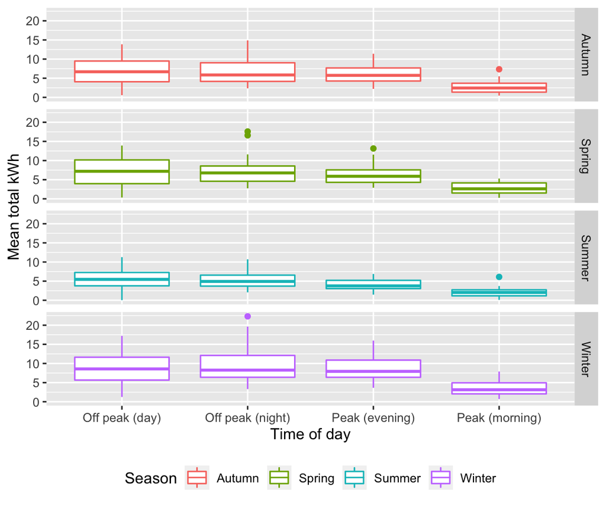

Figure 3.1: Mean total kWh per period by season (2015)

Figure 3.2 on the other hand shows the mean half-hourly kW demand per household by period and season and reflects the greater power demand in the evening and morning peak periods.

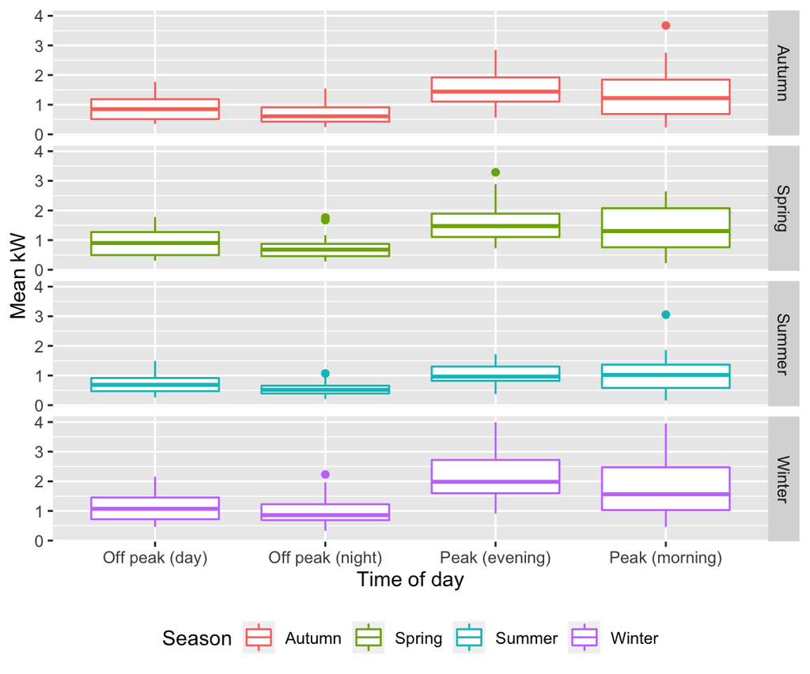

Figure 3.2: Mean kW per half hour by period and season (2015)

# 4 Peak Contribution

In this section we use the GREEN Grid residential sample to estimate the contribution of each appliance to peak demand. For this analysis we use demand data averaged over 30 minute intervals. We consider three different definitions of peak demand:

- Sample winter evenings 17:00 - 21:00.
  - Mean winter evening load:
    - find the average load across each circuit during the period
    - calculate the percentage contribution of each identified load type to this average peak load.
  - Maximum winter evening load
    - find the maximum half-hour demand for each household during the defined peak period
    - calculate the percentage contribution of each separately identifiable load type (lighting, hot water, heat pump, oven) in that half hour.
- Regional/network peak. In this case we:
  - find the 100 maximum regional network (GXP) peak half hours
  - calculate the mean contribution of each identifiable load to mean total load across all households in that region across these 100 half-hours
- Sample co-incident peak. In this case we:
  - find the half-hour across the sample which has the highest total combined demand
  - calculate mean contribution of each identifiable load to mean total load across all households in this half-hour

To do this last part we classify the circuit labels according to the load types mentioned above (see Table 8.1 in the Data Annex).

## 4.1 Winter (June - August) evenings 17:00 – 21:00

In this section we select the peak-period half hours for all households for the winter evening period and then calculate the mean demand for each dwelling over the period of peak demand.

Table 4.1 shows the winter mean demand (W) at ‘peak’ for each dwelling and circuit in 2015. The complete data table across all houses is saved as “Extracted mean demand by dwelling and circuit at ‘peak.’csv” and is supplied with the report.

Table 4.1: Example data: Extracted mean demand by dwelling and circuit at ‘peak’

| linkID | eecaCircuit | avgPeakDemandW |
| --- | --- | --- |
| rf_01 | Heat Pump or Heating | 2049.79 |
| rf_01 | Hot water | 135.69 |
| rf_01 | Lighting | 213.49 |
| rf_01 | Other | 342.92 |
| rf_01 | Oven | 70.21 |
| rf_01 | Total | 2812.10 |
| rf_06 | Hot water | 462.73 |
| rf_06 | Lighting | 416.24 |
| rf_06 | Other | 505.42 |
| rf_06 | Oven | 144.91 |

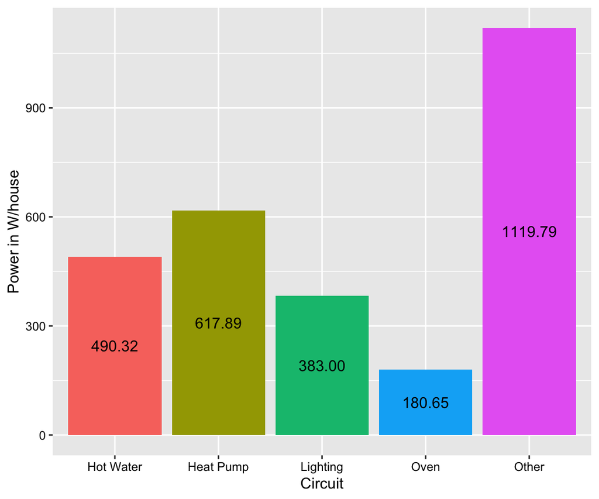

Figure 4.1: Mean contribution at ‘peak’ (17:00-21:00) by circuit in winter 2015

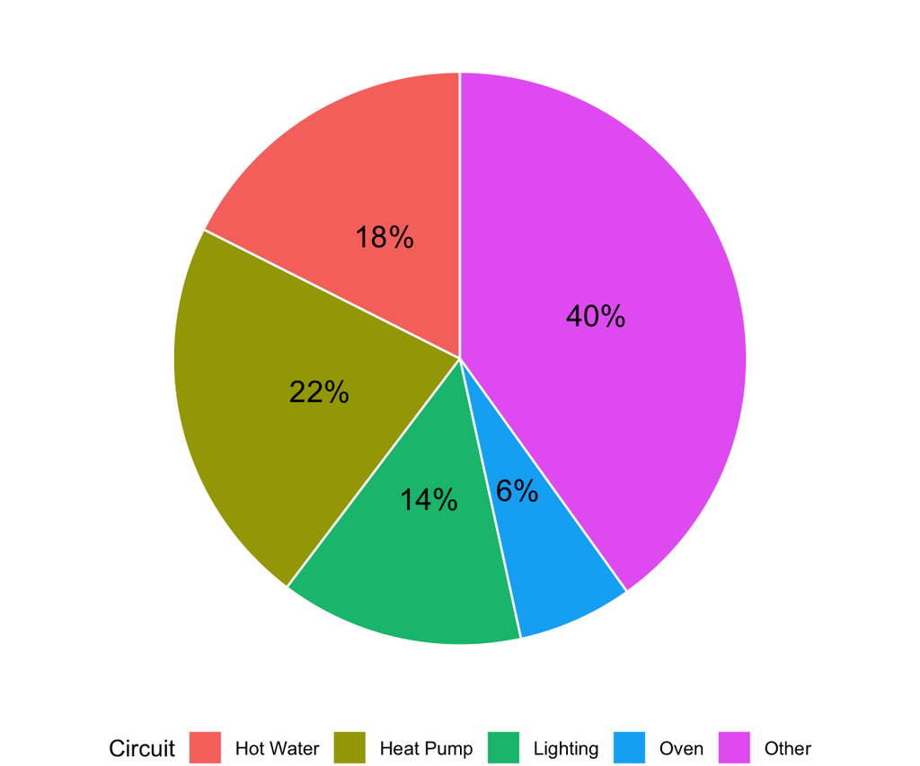

Figure 4.2: Mean percentage load contribution at ‘peak’ (17:00-21:00) by circuit in winter 2015

We have then used this data to calculate the mean contribution of each identifiable load to peak demand (time period 17:00-21:00) across the sample for winter in 2015. This is shown in Figure 4.1 and Figure 4.2 (as percentage contribution). On this measure, of the identifiable loads, Heat Pumps contributed the most to peak demand, followed by Hot Water, Lighting, and Oven. However overall ‘Other’ loads contributed the most at ~40% suggesting further research is needed to disaggregate this demand where possible (see Table 8.1) for circuits contributing to ‘Other.’

## 4.2 Maximum load per season (W)

In this section we extract the half-hour which had the maximum total load during the evening period (17:00-21:00) for each household in season.

Table 4.2 shows the winter maximum load half-hours for each dwelling and year during the winter peak period as defined above. In this data extract, NaN indicates that no circuit data was obtained for this dwelling in this specific time period. We also calculate the proportionate contribution of each identifiable load to the total load. The complete data table across all houses is saved as “Extracted seasonal peak load half-hour circuits.csv” and is supplied with the report.

Table 4.2: Example data: Extracted winter peak load half-hour circuits (NA indicates no such circuit)

| linkID | year | season | r_dateTime_nz | Heat Pump or Heating | Hot water | Lighting | Other | Oven | Total | pc_HW | pc_HP | pc_LI | pc_OV | pc_Other |
| --- | --- | --- | --- | --- | --- | --- | --- | --- | --- | --- | --- | --- | --- | --- |
| rf_01 | 2014 | Winter | 2014-06-20 19:00:00 | 6330.77 | 0.00 | 738.02 | 2048.04 | 1296.61 | 10413.44 | 0.00 | 0.61 | 0.07 | 0.12 | 0.20 |
| rf_01 | 2015 | Winter | 2015-08-09 18:30:00 | 7084.99 | 0.00 | 799.90 | 2260.26 | 0.00 | 10145.16 | 0.00 | 0.70 | 0.08 | 0.00 | 0.22 |
| rf_02 | 2014 | Winter | 2014-07-26 19:30:00 | 453.76 | 445.71 | 253.77 | 2152.72 | NA | 3305.96 | 0.13 | 0.14 | 0.08 | NA | 0.65 |
| rf_06 | 2014 | Winter | 2014-06-23 18:30:00 | NA | 0.00 | 1209.60 | 1093.66 | 3231.00 | 5534.26 | 0.00 | NA | 0.22 | 0.58 | 0.20 |
| rf_06 | 2015 | Winter | 2015-08-25 18:30:00 | NA | 1971.90 | 1231.02 | 2723.79 | 425.52 | 6352.23 | 0.31 | NA | 0.19 | 0.07 | 0.43 |
| rf_06 | 2016 | Winter | 2016-07-23 18:00:00 | NA | 1967.20 | 926.78 | 755.23 | 1558.86 | 5208.08 | 0.38 | NA | 0.18 | 0.30 | 0.15 |
| rf_06 | 2017 | Winter | 2017-08-13 18:00:00 | NA | 1963.50 | 632.05 | 2137.17 | 1725.01 | 6457.72 | 0.30 | NA | 0.10 | 0.27 | 0.33 |
| rf_06 | 2018 | Winter | 2018-06-06 17:00:00 | NA | 1920.51 | 345.87 | 2975.69 | 1901.05 | 7143.13 | 0.27 | NA | 0.05 | 0.27 | 0.42 |
| rf_07 | 2014 | Winter | 2014-07-16 17:00:00 | NA | NA | NA | 2483.62 | 1945.33 | 4428.95 | NA | NA | NA | 0.44 | 0.56 |
| rf_07 | 2015 | Winter | 2015-06-23 17:00:00 | NA | NA | NA | 4393.48 | 1284.66 | 5678.14 | NA | NA | NA | 0.23 | 0.77 |

We have then used this data to calculate the mean contribution of each identifiable load to peak demand (time period 17:00-21:00) for each season and year across the sample.

Results for 2015 are shown in Figure 4.3 and Figure 4.4 (as percentage contribution).

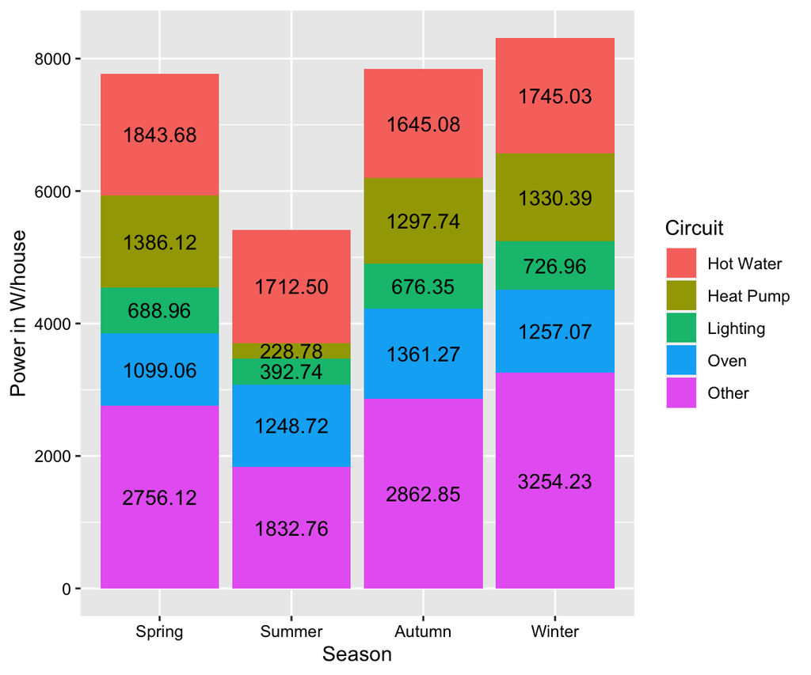

Figure 4.3: Mean contribution to peak demand (17:00-21:00) per season in 2015

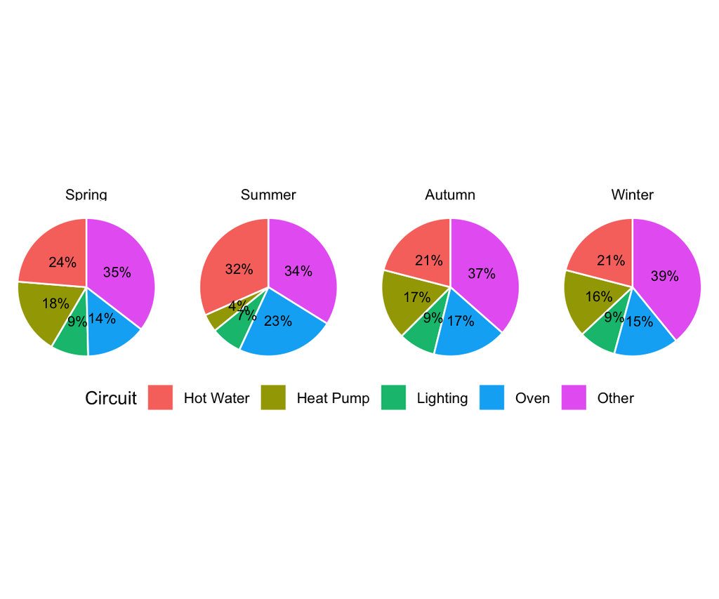

Figure 4.4: Mean percentage contribution to peak demand (17:00-21:00) for each season in 2015

## 4.3 Region/network coincident peak

In this section we focus on the contribution of these identifiable loads to regional peak demand. As 22 of the GREENGrid houses are based in Taranaki and 20 houses in Hawke’s Bay with further 2 pilot dwellings in Otago, we focus on the first two regions by separating the sample into the Hawke’s Bay and Taranaki sub-samples.

Within the Taranaki sample, 31% of the houses had heat pumps installed, 45% hot water cylinders, and 27% other heat sources. In contrast, the Hawke’s Bay sub-sample 90% had heat pumps, 90% hot water cylinder, and 36% other heat sources. The very small sample sizes and recruiting approaches limit the representativeness of the sample.

> Footnote: For further details see https://cfsotago.github.io/GREENGridData/householdAttributeProcessingReport_v1.0.html#51_main_heat_source and also ref to Part C

To determine the timing of the matching regional peaks, data on regional demand for the Hawke’s Bay and Taranaki Grid Exit Points (GXPs - see Table 4.3) was obtained from the Electricity Authority and for each GXP, the timestamps of the 100 half hours with the highest demand were identified. We then extracted the power demand of each dwelling in each of the two regions during these 100 half hours for analysis.

Table 4.3: GXPs used

| node | region name |
| --- | --- |
| CST0331 | Taranaki |
| HUI0331 | Taranaki |
| HWA0331 | Taranaki |
| NPL0331 | Taranaki |
| OPK0331 | Taranaki |
| SFD0331 | Taranaki |
| WGN0331 | Taranaki |
| FHL0331 | Hawke’s bay |
| RDF0331 | Hawke’s bay |
| WTU0331 | Hawke’s bay |

### 4.3.1 Hawke’s Bay

Table 4.4 presents example data of the extracted peak half-hours by circuit for 2015 for a Hawke’s Bay dwellings. The complete data table is saved as “Extracted peak load half-hour circuits for Hawke’s Bay.csv” and is supplied with the report.

Table 4.4: Example data: Extracted peak load half-hour circuits for Hawke’s Bay (NaN indicates no such circuit)

| linkID | year | season | r_dateTime_nz | Heat Pump or Heating | Hot water | Lighting | Other | Oven | Total |
| --- | --- | --- | --- | --- | --- | --- | --- | --- | --- |
| rf_01 | 2015 | Winter | 2015-06-05 17:30:00 | 3276.65 | 0.00 | 354.83 | 306.55 | 0.00 | 3938.03 |
| rf_01 | 2015 | Winter | 2015-06-08 17:30:00 | 3265.45 | 0.00 | 133.31 | 221.43 | 0.00 | 3620.19 |
| rf_01 | 2015 | Winter | 2015-06-08 19:00:00 | 3377.16 | 0.00 | 157.63 | 282.54 | 0.00 | 3817.33 |
| rf_01 | 2015 | Winter | 2015-06-15 17:30:00 | 4232.71 | 0.00 | 382.41 | 310.89 | 825.96 | 5751.97 |
| rf_01 | 2015 | Winter | 2015-06-15 18:00:00 | 4064.93 | 0.00 | 328.44 | 297.37 | 128.42 | 4819.17 |
| rf_01 | 2015 | Winter | 2015-06-16 17:30:00 | 4196.80 | 813.33 | 326.00 | 1098.91 | 6.66 | 6441.70 |
| rf_01 | 2015 | Winter | 2015-06-17 17:30:00 | 3993.92 | 1042.07 | 319.77 | 132.13 | 0.00 | 5487.88 |
| rf_01 | 2015 | Winter | 2015-06-17 18:30:00 | 4416.28 | 0.00 | 453.21 | 1058.01 | 605.07 | 6532.57 |
| rf_01 | 2015 | Winter | 2015-06-17 19:30:00 | 3813.54 | 0.00 | 201.17 | 251.09 | 0.00 | 4265.79 |
| rf_01 | 2015 | Winter | 2015-06-22 17:00:00 | 3866.76 | 0.00 | 434.06 | 319.35 | 0.00 | 4620.17 |

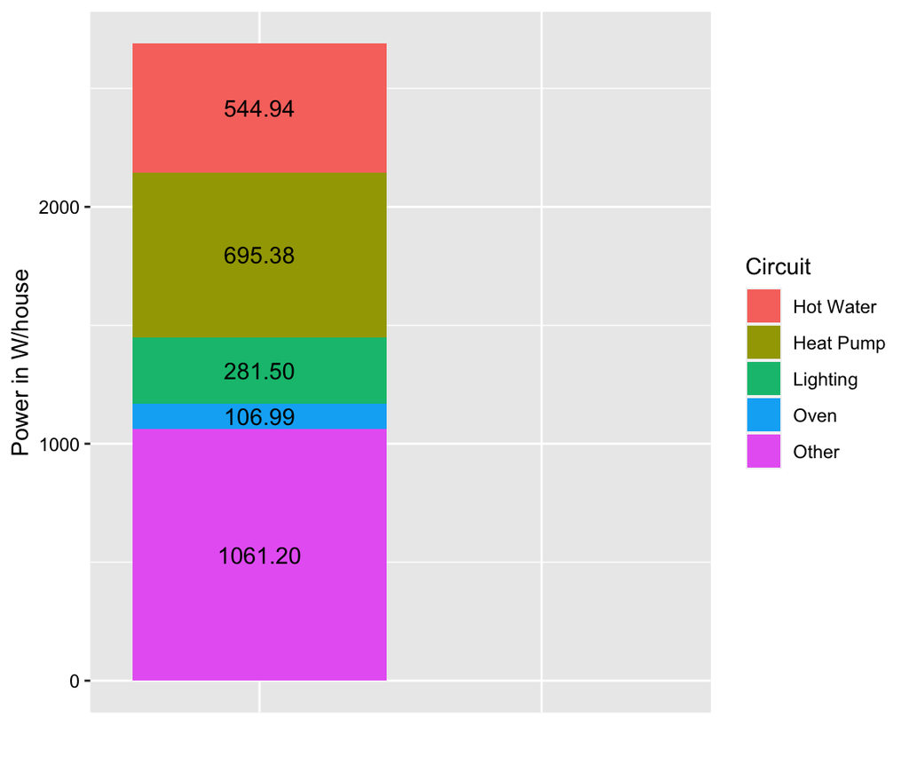

Figure 4.5: Mean contribution of each identifiable load in the sample to the Hawke’s bay regional peak (100 half hours with the highest demand at Hawkes Bay GXP) for 2015

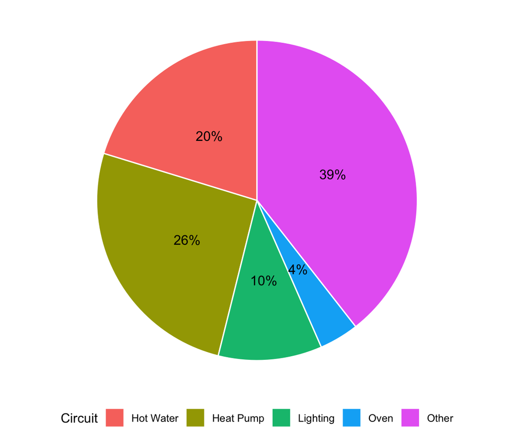

Figure 4.6: Percentage contribution to peak demand for top 100 GXP half hours in Hawkes Bay for 2015

### 4.3.2 Taranaki

Table 4.5 presents example data of the extracted peak half-hours by circuit for 2015 for the Taranaki houses. The complete data table is saved as “Extracted peak load half-hour circuits for Taranaki.csv” and is supplied with the report.

Table 4.5: Example data: Extracted peak load half-hour circuits (NaN indicates no such circuit)

| linkID | year | season | r_dateTime_nz | Heat Pump or Heating | Hot water | Lighting | Other | Oven | Total |
| --- | --- | --- | --- | --- | --- | --- | --- | --- | --- |
| rf_01 | 2015 | Winter | 2015-06-03 17:30:00 | 3217.26 | 0 | 627.81 | 480.53 | 1520.99 | 5846.58 |
| rf_01 | 2015 | Winter | 2015-06-03 18:00:00 | 2626.62 | 0 | 486.23 | 183.88 | 0.00 | 3296.74 |
| rf_01 | 2015 | Winter | 2015-06-22 17:30:00 | 3672.64 | 0 | 568.55 | 593.82 | 284.81 | 5119.82 |
| rf_01 | 2015 | Winter | 2015-06-22 18:00:00 | 3884.40 | 0 | 670.60 | 196.28 | 1227.56 | 5978.85 |
| rf_01 | 2015 | Winter | 2015-06-22 18:30:00 | 3415.85 | 0 | 702.64 | 172.78 | 1255.81 | 5547.09 |
| rf_01 | 2015 | Winter | 2015-06-23 17:30:00 | 4049.44 | 0 | 501.81 | 720.67 | 0.00 | 5271.92 |
| rf_01 | 2015 | Winter | 2015-06-23 18:00:00 | 4404.86 | 0 | 346.77 | 419.84 | 0.00 | 5171.46 |
| rf_01 | 2015 | Winter | 2015-06-23 18:30:00 | 5842.13 | 0 | 404.60 | 1360.91 | 0.00 | 7607.64 |
| rf_01 | 2015 | Winter | 2015-06-24 17:30:00 | 4318.96 | 0 | 582.43 | 180.04 | 175.79 | 5257.22 |
| rf_01 | 2015 | Winter | 2015-06-24 18:00:00 | 4126.43 | 0 | 579.92 | 571.14 | 843.46 | 6120.95 |

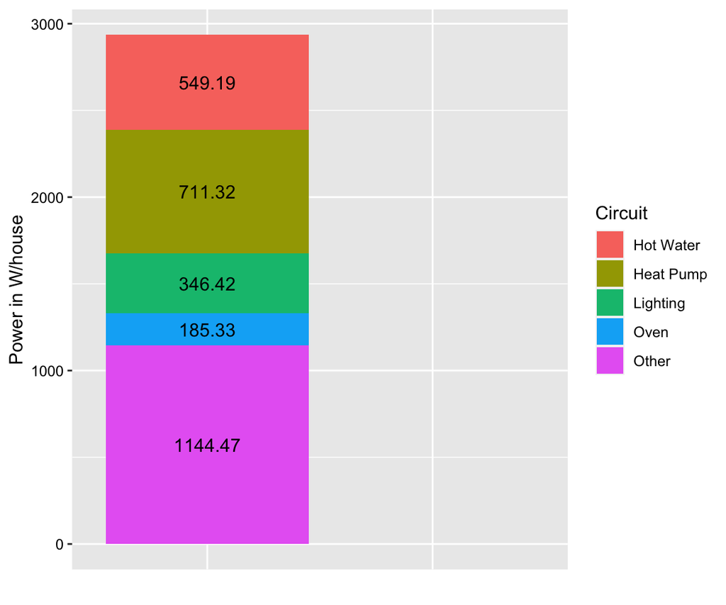

Figure 4.7: Mean contribution of each identifiable load to peak demand in Taranaki in 2015

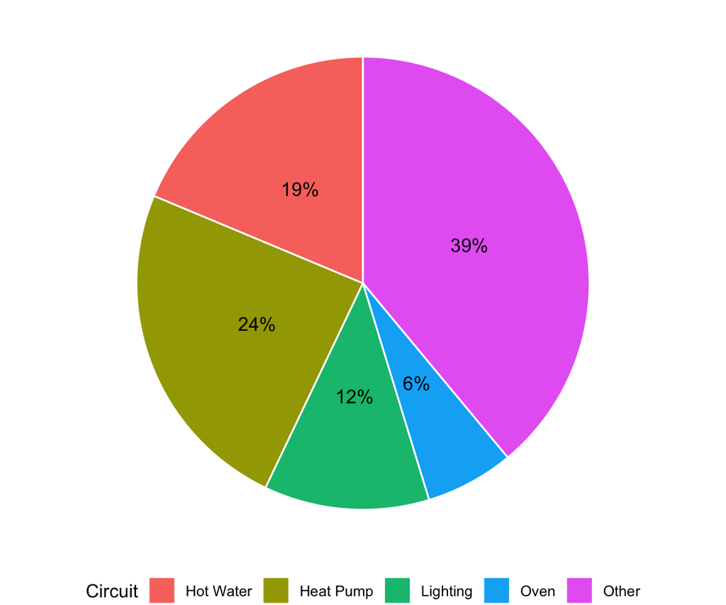

Figure 4.8: Percentage contribution to demand during top 100 GXP half hours in Taranaki for 2015

## 4.4 Sample coincident peak

Table 4.6: Example data: Extracted winter peak load half-hours in descending order for 2015

| eecaCircuit | date | season | year | obsHalfHour | sumOfmeanPowerW | nDwellings | averagePowerW |
| --- | --- | --- | --- | --- | --- | --- | --- |
| Total | 2015-06-28 | Winter | 2015 | 18:00:00 | 94539.27 | 27 | 3501.45 |
| Total | 2015-06-24 | Winter | 2015 | 07:00:00 | 93517.79 | 28 | 3339.92 |
| Total | 2015-06-23 | Winter | 2015 | 18:00:00 | 91330.16 | 28 | 3261.79 |
| Total | 2015-08-21 | Winter | 2015 | 07:00:00 | 87393.28 | 27 | 3236.79 |
| Total | 2015-06-28 | Winter | 2015 | 18:30:00 | 83632.68 | 27 | 3097.51 |
| Total | 2015-06-23 | Winter | 2015 | 17:30:00 | 86435.42 | 28 | 3086.98 |
| Total | 2015-06-26 | Winter | 2015 | 07:00:00 | 86301.30 | 28 | 3082.19 |
| Total | 2015-06-23 | Winter | 2015 | 07:00:00 | 85940.64 | 28 | 3069.31 |
| Total | 2015-08-10 | Winter | 2015 | 20:00:00 | 82334.81 | 27 | 3049.44 |
| Total | 2015-08-12 | Winter | 2015 | 07:00:00 | 81883.67 | 27 | 3032.73 |

Figure 4.9 shows the mean contribution of each identifiable load for the sample to the top 20 identified peak half hours cross the sample. The results show that on average Heat Pumps contribute the most, followed by Hot Water and Lighting. The plot also shows that ‘Other’ has a large contribution. Again, these results should be viewed with some caution due to the non-representative nature of the GREEN Grid sample. While they represent the sample co-incident peak contributions, we cannot assume that this is representative of all New Zealand dwellings.

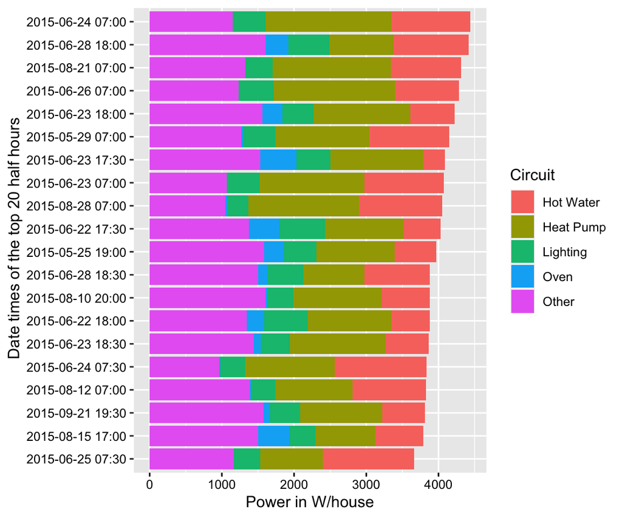

Figure 4.9: Mean appliance contribution to peak demand for the top 20 half hours in the sample (ordered by total load)

# 5 Annual Contribution

This section presents annual and seasonal energy consumption (in kWh) for each identifiable load. This analysis considers the year 2015. Figure 5.1 shows the annual total energy consumption (in kWh) for the identifiable loads in a [box and whisker plot](https://ggplot2.tidyverse.org/reference/geom_boxplot.html) to show the median, 25%/75% quantiles, whiskers and outliers. Hot Water consumes the most energy per year with a pronounced variation between houses. Lighting, Heat Pump, and Oven follow. “Other” clearly drive large inter-household variation and, as noted above, should be a focus of further work.

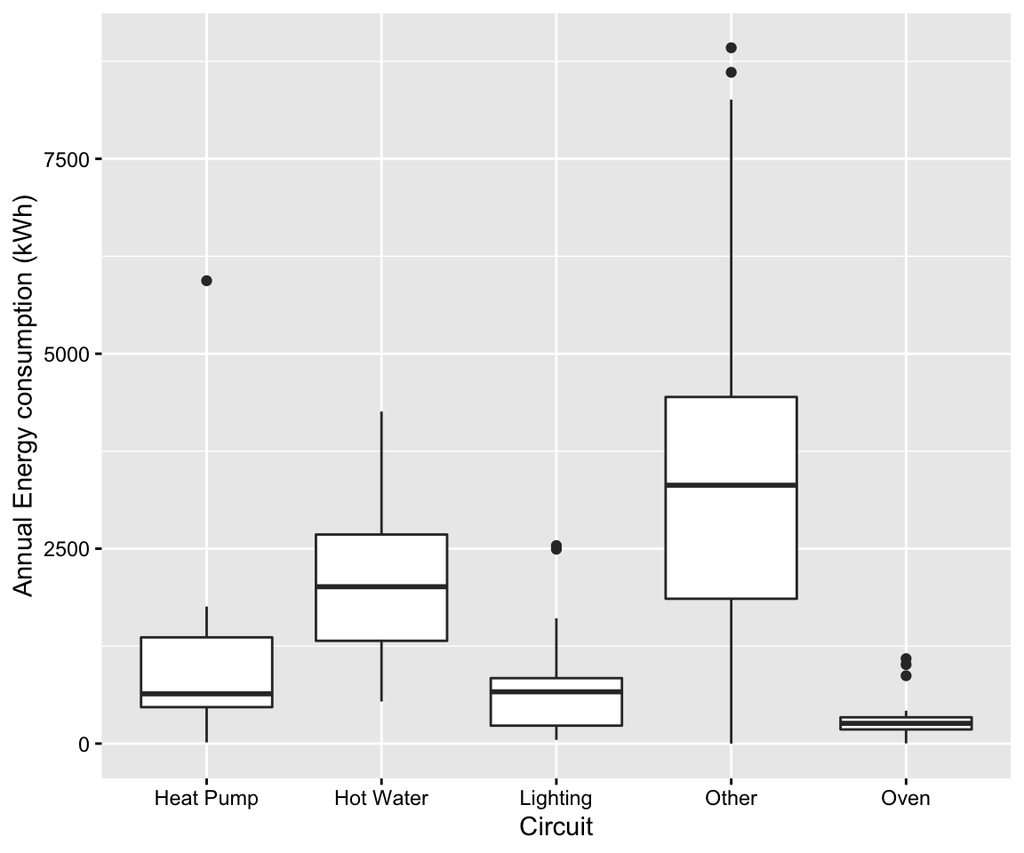

Figure 5.1: Box and whisker plot of annual energy consumption (per house) of each identifiable load for 2015

Figure 5.1 conceals the significant variation in demand between seasons and in the following we use [density plots](https://ggplot2.tidyverse.org/reference/geom_density.html) to show the shape of the distribution for each circuit by season.

Figure 5.2 shows the distribution of seasonal energy consumption in kWh across all houses for Hot Water in 2015 using a density plot. This shows that most energy consumption for Hot Water is in winter, followed by spring and autumn. Energy consumption for hot water in summer is substantially lower with a distinctively different pattern to both the spring/autumn seasons and winter.

> Example histogram saved as .png

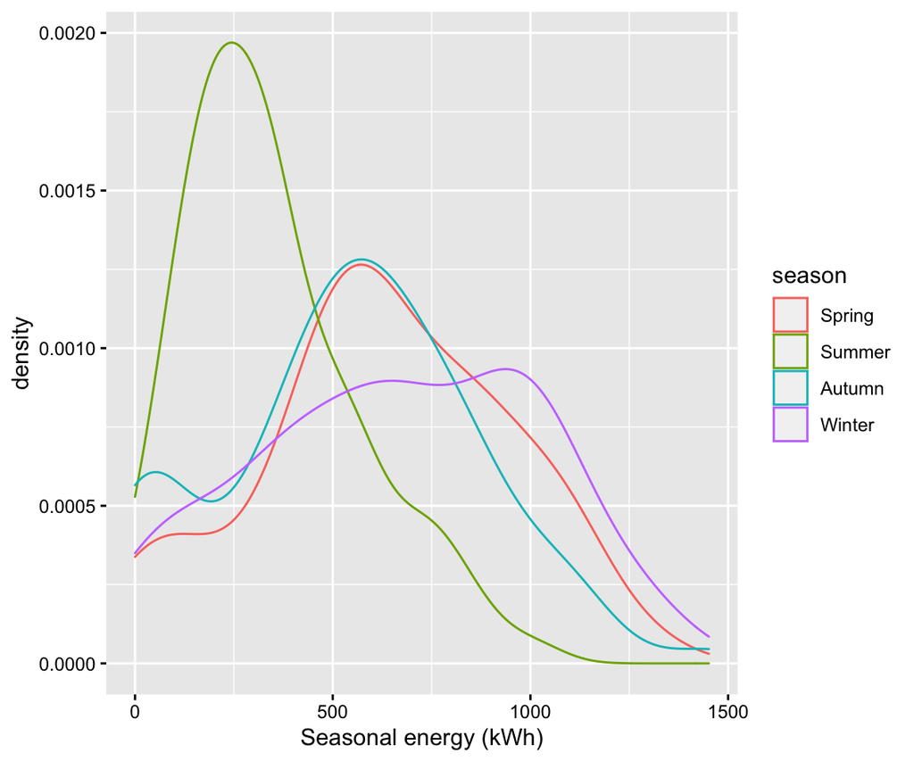

Figure 5.2: Distribution of seasonal energy consumption for Hot Water for all houses for 2015

In contrast, Figure 5.3 presents a similar density plot for Heat Pumps. As expected, most energy consumption is in winter. In summer, total energy consumption is mostly 0 (appliance is turned off). Only a few observations registered energy consumption in summer which may be cooling.

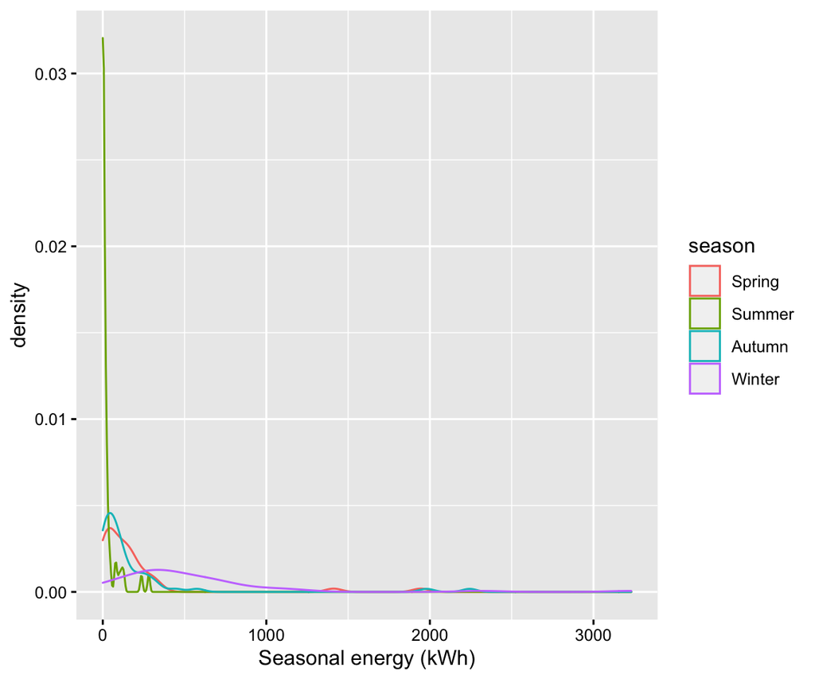

Figure 5.3: Distribution of seasonal energy consumption for Heat Pumps for all houses for 2015

Energy consumption of Lighting is particularly apparent in spring, autumn, and winter as presented in Figure 5.4. Less energy consumption is identified in summer.

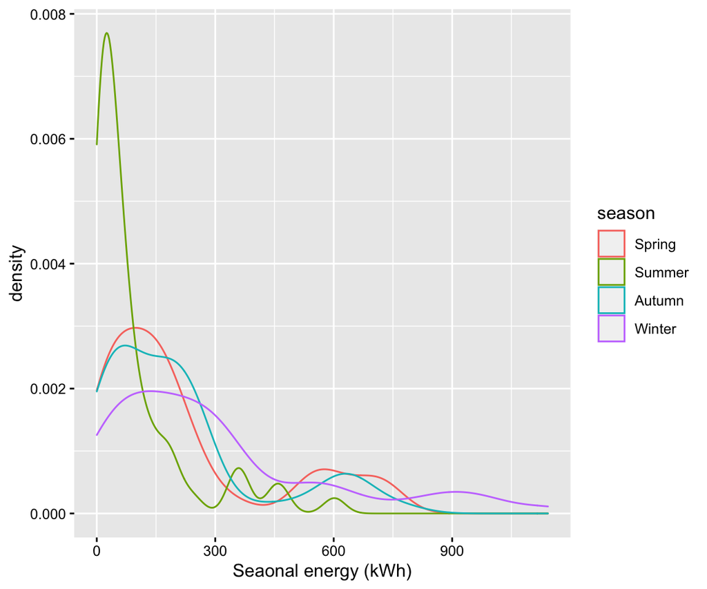

Figure 5.4: Distribution of seasonal energy consumption for Lighting for all houses for 2015

For ovens, there is less seasonal variation in seasonal energy consumption as shown in Figure 5.5. Again, energy consumption in summer is less than in other seasons.

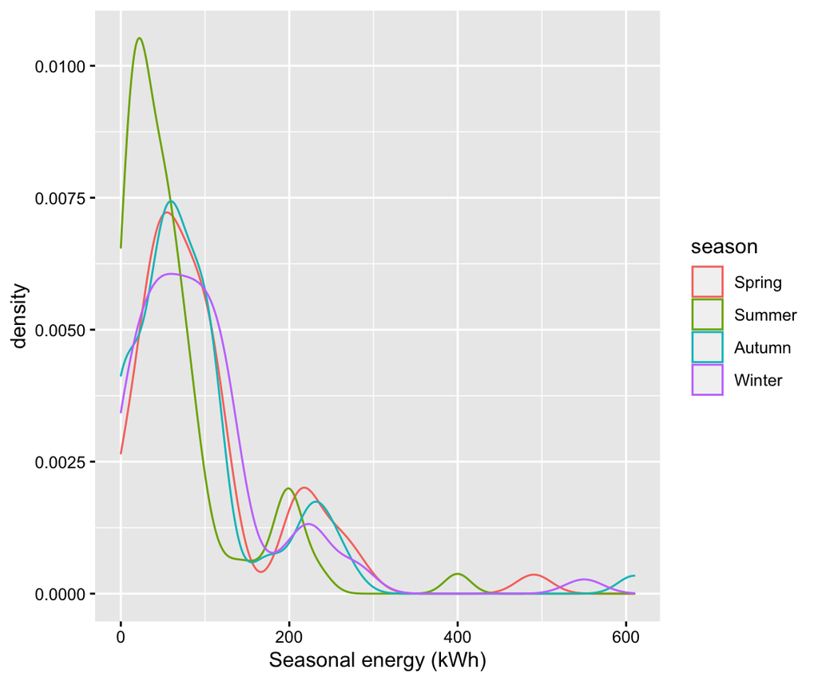

Figure 5.5: Distribution of seasonal energy consumption for Ovens for all houses for 2015

For “Other,” there is a lot of seasonal variation in seasonal energy consumption as shown in Figure 5.6. As this circuit contains appliances not further specified it is difficult to identify the appliance causing this energy consumption, particularly in summer. Therefore, further research is necessary.

[figure not shown]

Figure 5.6: Distribution of seasonal energy consumption for Other for all houses for 2015

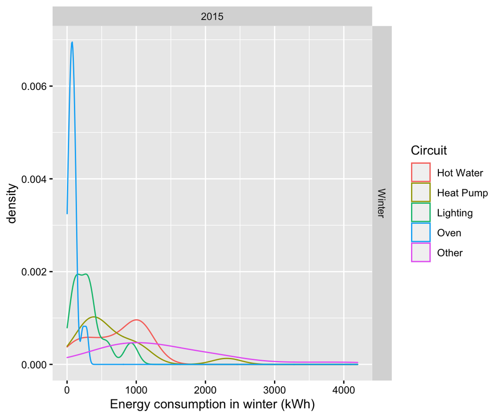

Figure 5.7: Distribution of winter 2015 total energy consumption for all circuits for all houses

Finally, Figure 5.7 shows the variation in all circuits for winter 2015. On average, Hot Water used the most energy, followed by Heat Pumps, Lighting, and Ovens but ‘Other’ shows a wide variation which again warrants further investigation.

# 6 Load Factor

The Load Factor (LF) is defined as the ratio of mean demand (W) and the peak demand (W) for each load. In this section we define peak demand to be the mean demand between 17:00-21:00 in winter. The LF provides a measure of how much the load contributes to peak. If the LF for a particular load is 1 then the load is flat. If the LF is less than 1 this shows that the load disproportionately contributes to the peak. Note that values greater than 1 indicate that demand during the peak is reduced below the mean. An alternative measure is given by the conservation load factor defined by:

```
`CLF = Peak W/((Average W*8760)/1000)`
```

The CLF represents the ratio of the power demand at peak to the annual energy consumption over the year (in W/kWh). The advantage of the CLF is that is gives a larger value when the load makes larger contribution to the peak. Table 6.1 shows the first rows of our calculation of LF and CLF.

Table 6.1: Example data: Extracted load factor by household and circuit

| linkID | eecaCircuit | avgPeakDemandW | avgDemandW | LoadFactor | CLF |
| --- | --- | --- | --- | --- | --- |
| rf_06 | Hot water | 462.73 | 405.74 | 0.88 | 0.13 |
| rf_06 | Lighting | 416.24 | 161.38 | 0.39 | 0.29 |
| rf_06 | Other | 505.42 | 437.39 | 0.87 | 0.13 |
| rf_06 | Oven | 144.91 | 24.02 | 0.17 | 0.69 |
| rf_06 | Total | 1539.35 | 1049.32 | 0.68 | 0.17 |
| rf_13 | Heat Pump or Heating | 972.10 | 179.94 | 0.19 | 0.62 |

The full data table containing LFs and CLFs (if available) for each house is saved as “Extracted load factor by household and circuit.csv” and supplied with the report.

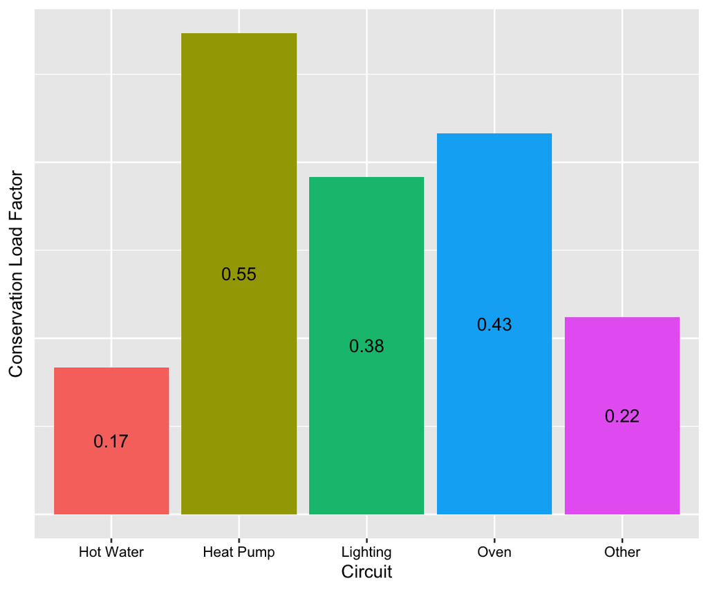

Figure 6.1: Mean Conservation Load Factor by circuit for peak demand (17:00-21:00) in winter 2015

Note that these numbers are means over all households, dates, and times for 2015. This means that each household contributes equally to the mean and it is not weighted by its total demand. For example, the load factor from households with very low hot water demand will contribute equally to the mean.

In addition, it is clear that the mean CLF over all houses is skewed by some houses with CLF > 0.9 as Figure 6.2 shows.

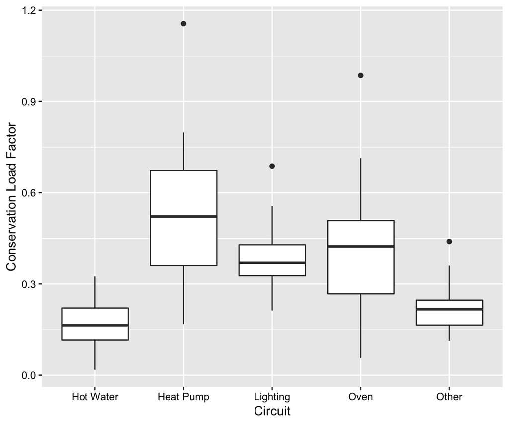

Figure 6.2: Box and whiskers plot of Conservation Load Factor distribution by circuit for peak demand (17:00-21:00) in winter 2015

# 7 Summary

This report has used the GREEN Grid sample of circuit-level household electricity demand data to analyse the contribution of heat pumps, hot water, lighting, and ovens to peak demand. Calculations have been carried out using a variety of definitions of “peak.” In addition, we also calculated the annual energy consumption of each identifiable load in the sample and a conservation load factor which is a measure of peak demand to annual energy consumption for each identifiable load.

The results show plausible results, however there are a number of key considerations in extrapolating these results:

1. Unidentified loads represented a significant contribution in the sample
2. Means calculated over the sample can significantly distort the results
3. The non-representative nature of the sample means that the results cannot be considered to be representative of New Zealand households

These short comings suggest that future work should focus on (1) collecting data from a more representative sample of New Zealand households, (2) ensuring that appliances are identified on circuits (especially electric heaters); (3) variation across the sample be accounted for in any results.

# 8 Data Annex

## 8.1 Categorised circuits

Table 8.1 shows the categorised circuit labels used in this analysis. It would be relatively easy to adjust these definitions in future work if required.

Table 8.1: Definition of ‘eeca circuits’ (columns) based on original circuits (rows). Values are the count of half-hours in the complete power data

|  | Heat Pump or Heating | Hot water | Lighting | Other | Oven | Total |
| --- | --- | --- | --- | --- | --- | --- |
| Calculated_other | 0 | 0 | 0 | 1460383 | 0 | 0 |
| Heat Pump$2092 | 51639 | 0 | 0 | 0 | 0 | 0 |
| Heat Pump$2598 | 60754 | 0 | 0 | 0 | 0 | 0 |
| Heat Pump$2826 | 30311 | 0 | 0 | 0 | 0 | 0 |
| Heat Pump$4130 | 32529 | 0 | 0 | 0 | 0 | 0 |
| Heat Pump$4134 | 58798 | 0 | 0 | 0 | 0 | 0 |
| Heat Pump$4150 | 53554 | 0 | 0 | 0 | 0 | 0 |
| Heat Pump$4154 | 58753 | 0 | 0 | 0 | 0 | 0 |
| Heat Pump$4175 | 29556 | 0 | 0 | 0 | 0 | 0 |
| Heat Pump$4190 | 45806 | 0 | 0 | 0 | 0 | 0 |
| Heat Pump$4196 | 18044 | 0 | 0 | 0 | 0 | 0 |
| Heat Pump$4204 | 58693 | 0 | 0 | 0 | 0 | 0 |
| Heat Pump$4219 | 2885 | 0 | 0 | 0 | 0 | 0 |
| Heat Pump$4223 | 24373 | 0 | 0 | 0 | 0 | 0 |
| Heating$1576 | 19412 | 0 | 0 | 0 | 0 | 0 |
| Heating$1633 | 28401 | 0 | 0 | 0 | 0 | 0 |
| Hot Water (2 elements)$4247 | 0 | 51274 | 0 | 0 | 0 | 0 |
| Hot Water - Controlled (HEMS)$2081 | 0 | 72954 | 0 | 0 | 0 | 0 |
| Hot Water - Controlled$2094 | 0 | 51639 | 0 | 0 | 0 | 0 |
| Hot Water - Controlled$2102 | 0 | 70291 | 0 | 0 | 0 | 0 |
| Hot Water - Controlled$2110 | 0 | 18124 | 0 | 0 | 0 | 0 |
| Hot Water - Controlled$2129 | 0 | 18032 | 0 | 0 | 0 | 0 |
| Hot Water - Controlled$2208 | 0 | 72683 | 0 | 0 | 0 | 0 |
| Hot Water - Controlled$2236 | 0 | 62880 | 0 | 0 | 0 | 0 |
| Hot Water - Controlled$2248 | 0 | 62810 | 0 | 0 | 0 | 0 |
| Hot Water - Controlled$2679 | 0 | 12416 | 0 | 0 | 0 | 0 |
| Hot Water - Controlled$2825 | 0 | 30311 | 0 | 0 | 0 | 0 |
| Hot Water - Controlled$4135 | 0 | 58798 | 0 | 0 | 0 | 0 |
| Hot Water - Controlled$4144 | 0 | 53402 | 0 | 0 | 0 | 0 |
| Hot Water - Controlled$4155 | 0 | 58753 | 0 | 0 | 0 | 0 |

[output cut: 59 more lines]

## 8.2 Original data description

Descriptive statistics for aggregate half hourly power data for all households and all circuits:

Table 8.2: Data summary

| Name | powerDT |
| --- | --- |
| Number of rows | 6339776 |
| Number of columns | 22 |
| Key | date, obsHalfHour |
| _______________________ |  |
| Column type frequency: |  |
| character | 9 |
| Date | 1 |
| difftime | 1 |
| numeric | 9 |
| POSIXct | 2 |
| ________________________ |  |
| Group variables | None |

**Variable type: character**

| skim_variable | n_missing | complete_rate | min | max | empty | n_unique | whitespace |
| --- | --- | --- | --- | --- | --- | --- | --- |
| linkID | 0 | 1.00 | 5 | 6 | 0 | 37 | 0 |
| circuit | 0 | 1.00 | 9 | 37 | 0 | 89 | 0 |
| season | 116097 | 0.98 | 6 | 6 | 0 | 4 | 0 |
| peak | 116097 | 0.98 | 4 | 10 | 0 | 3 | 0 |
| circuitLabel | 116097 | 0.98 | 4 | 37 | 0 | 27 | 0 |
| circuitID | 2822274 | 0.55 | 4 | 4 | 0 | 87 | 0 |
| eecaCircuit | 0 | 1.00 | 4 | 20 | 0 | 6 | 0 |
| eecaCircuitOrig | 0 | 1.00 | 4 | 20 | 0 | 6 | 0 |
| ba_peak | 0 | 1.00 | 14 | 16 | 0 | 4 | 0 |

**Variable type: Date**

| skim_variable | n_missing | complete_rate | min | max | median | n_unique |
| --- | --- | --- | --- | --- | --- | --- |
| date | 116097 | 0.98 | 2014-01-06 | 2018-08-01 | 2016-03-20 | 1613 |

**Variable type: difftime**

| skim_variable | n_missing | complete_rate | min | max | median | n_unique |
| --- | --- | --- | --- | --- | --- | --- |
| obsHalfHour | 116097 | 0.98 | 0 secs | 84600 secs | 12:00:00 | 48 |

**Variable type: numeric**

| skim_variable | n_missing | complete_rate | mean | sd | p0 | p25 | p50 | p75 | p100 | hist |
| --- | --- | --- | --- | --- | --- | --- | --- | --- | --- | --- |
| nObs | 116097 | 0.98 | 29.98 | 0.61 | 1.00 | 30 | 30.00 | 30.00 | 60.00 | ▁▁▇▁▁ |
| meanPowerW | 197941 | 0.97 | 424.86 | 737.26 | -2356.33 | 0 | 138.82 | 492.67 | 10981.59 | ▇▅▁▁▁ |
| sdPowerW | 1460654 | 0.77 | 184.43 | 373.88 | 0.00 | 0 | 0.72 | 109.57 | 5068.08 | ▇▁▁▁▁ |
| minPowerW | 1515182 | 0.76 | 195.84 | 512.82 | 0.00 | 0 | 0.00 | 163.82 | 9600.58 | ▇▁▁▁▁ |
| maxPowerW | 1487394 | 0.77 | 727.57 | 1293.36 | 0.00 | 0 | 18.44 | 791.49 | 27759.00 | ▇▁▁▁▁ |
| month | 116097 | 0.98 | 6.48 | 3.33 | 1.00 | 4 | 6.00 | 9.00 | 12.00 | ▇▆▆▆▇ |
| year | 0 | 1.00 | 2015.86 | 1.16 | 2014.00 | 2015 | 2016.00 | 2017.00 | 2018.00 | ▃▇▆▅▂ |
| energyWh | 197941 | 0.97 | 212.43 | 368.63 | -1178.17 | 0 | 69.41 | 246.33 | 5490.79 | ▇▅▁▁▁ |
| hour | 0 | 1.00 | 11.50 | 6.92 | 0.00 | 6 | 12.00 | 18.00 | 23.00 | ▇▇▆▇▇ |

**Variable type: POSIXct**

| skim_variable | n_missing | complete_rate | min | max | median | n_unique |
| --- | --- | --- | --- | --- | --- | --- |
| r_dateTimeHalfHour | 116097 | 0.98 | 2014-01-06 03:00:00 | 2018-08-01 11:30:00 | 2016-03-20 10:00:00 | 77345 |
| r_dateTime_nz | 0 | 1.00 | 2014-01-06 03:00:00 | 2018-08-01 11:30:00 | 2016-03-24 09:30:00 | 77345 |

The following tables show descriptive statistics for the meanPowerW values for each circuit by household.

Table 8.3: rf_24: Mean of half-hourly mean power (W) by original circuit label & EECA circuit type

| circuit | eecaCircuit | meanPowerW | minPowerW | maxPowerW | nObs |
| --- | --- | --- | --- | --- | --- |
| Calculated_other | Other | NaN | Inf | -Inf | 70291 |
| Hot Water - Controlled$2102 | Hot water | 464.31 | 0 | 3196.6 | 70291 |

Table 8.3: rf_41: Mean of half-hourly mean power (W) by original circuit label & EECA circuit type

| circuit | eecaCircuit | meanPowerW | minPowerW | maxPowerW | nObs |
| --- | --- | --- | --- | --- | --- |
| Calculated_other | Other | NaN | Inf | -Inf | 45806 |
| Heat Pump$4190 | Heat Pump or Heating | 51.10 | 0 | 3579.52 | 45806 |
| Lighting$4189 | Lighting | 185.42 | 0 | 1760.21 | 18346 |

Table 8.3: rf_01: Mean of half-hourly mean power (W) by original circuit label & EECA circuit type

| circuit | eecaCircuit | meanPowerW | minPowerW | maxPowerW | nObs |
| --- | --- | --- | --- | --- | --- |
| Calculated_other | Other | 327.52 | 35.63 | 4263.54 | 28401 |
| Heating$1633 | Heat Pump or Heating | 960.24 | 0.00 | 7084.99 | 28401 |
| Hot water$1636 | Hot water | 216.75 | 0.00 | 1874.65 | 28401 |
| Lights$1635 | Lighting | 118.30 | 0.00 | 1102.66 | 28401 |
| Range$1637 | Oven | 39.21 | 0.00 | 3550.98 | 28401 |
| imputedTotalDemand_circuitsToSum_v1.1 | Total | 1662.02 | 90.72 | 10981.59 | 28401 |

Table 8.3: rf_02: Mean of half-hourly mean power (W) by original circuit label & EECA circuit type

| circuit | eecaCircuit | meanPowerW | minPowerW | maxPowerW | nObs |
| --- | --- | --- | --- | --- | --- |
| Calculated_other | Other | 302.54 | -11.91 | 3923.84 | 19412 |
| Heating$1576 | Heat Pump or Heating | 160.75 | 0.00 | 3360.73 | 19412 |
| Hot Water$1574 | Hot water | 234.30 | 0.00 | 2215.74 | 19412 |
| Lights$1577 | Lighting | 23.67 | 0.00 | 559.34 | 19412 |
| imputedTotalDemand_circuitsToSum_v1.1 | Total | 721.26 | 25.47 | 7427.87 | 19412 |

Table 8.3: rf_23: Mean of half-hourly mean power (W) by original circuit label & EECA circuit type

| circuit | eecaCircuit | meanPowerW | minPowerW | maxPowerW | nObs |
| --- | --- | --- | --- | --- | --- |
| Calculated_other | Other | 848.70 | -984.17 | 5256.37 | 72954 |
| Hot Water - Controlled (HEMS)$2081 | Hot water | 256.58 | 0.00 | 1459.96 | 72954 |
| Oven$2085 | Oven | 38.78 | 0.00 | 3301.91 | 72954 |
| imputedTotalDemand_circuitsToSum_v1.1 | Total | 1161.19 | 0.06 | 6676.90 | 72954 |

Table 8.3: rf_08: Mean of half-hourly mean power (W) by original circuit label & EECA circuit type

| circuit | eecaCircuit | meanPowerW | minPowerW | maxPowerW | nObs |
| --- | --- | --- | --- | --- | --- |
| Calculated_other | Other | 657.29 | 160.3 | 5419.33 | 51639 |
| Heat Pump$2092 | Heat Pump or Heating | 67.13 | 0.0 | 2036.82 | 51639 |
| Hot Water - Controlled$2094 | Hot water | 272.31 | 0.0 | 2366.14 | 51639 |
| Oven & Hob$2091 | Oven | 48.22 | 0.0 | 3480.85 | 51639 |
| imputedTotalDemand_circuitsToSum_v1.1 | Total | 1044.94 | 244.9 | 7882.45 | 51639 |

Table 8.3: rf_20: Mean of half-hourly mean power (W) by original circuit label & EECA circuit type

| circuit | eecaCircuit | meanPowerW | minPowerW | maxPowerW | nObs |
| --- | --- | --- | --- | --- | --- |
| Calculated_other | Other | 277.20 | -321.81 | 3179.27 | 18124 |
| Hot Water - Controlled$2110 | Hot water | 274.16 | 0.00 | 3163.17 | 18124 |
| Oven & Kitchen Appliances$2108 | Oven | 262.49 | 39.13 | 3397.60 | 18124 |
| imputedTotalDemand_circuitsToSum_v1.1 | Total | 814.12 | 4.67 | 7239.91 | 18124 |

Table 8.3: rf_18: Mean of half-hourly mean power (W) by original circuit label & EECA circuit type

| circuit | eecaCircuit | meanPowerW | minPowerW | maxPowerW | nObs |
| --- | --- | --- | --- | --- | --- |
| Calculated_other | Other | 1053.84 | 34.91 | 7510.38 | 18032 |
| Hot Water - Controlled$2129 | Hot water | 348.43 | 0.00 | 2107.45 | 18032 |
| Oven$2132 | Oven | 36.55 | 0.00 | 2143.60 | 18032 |
| imputedTotalDemand_circuitsToSum_v1.1 | Total | 1444.29 | 34.91 | 10051.11 | 18032 |

Table 8.3: rf_13: Mean of half-hourly mean power (W) by original circuit label & EECA circuit type

| circuit | eecaCircuit | meanPowerW | minPowerW | maxPowerW | nObs |
| --- | --- | --- | --- | --- | --- |
| Calculated_other | Other | 1003.64 | 141.73 | 6217.79 | 72683 |
| Hot Water - Controlled$2208 | Hot water | 198.86 | 0.00 | 2311.01 | 72683 |
| Oven & Hob$2210 | Oven | 107.58 | 0.00 | 3689.63 | 72683 |
| Upstairs Heat Pumps$2211 | Heat Pump or Heating | 150.10 | 0.00 | 2762.93 | 72683 |
| imputedTotalDemand_circuitsToSum_v1.1 | Total | 1455.80 | 141.73 | 9575.83 | 72683 |

Table 8.3: rf_22: Mean of half-hourly mean power (W) by original circuit label & EECA circuit type

| circuit | eecaCircuit | meanPowerW | minPowerW | maxPowerW | nObs |
| --- | --- | --- | --- | --- | --- |
| Calculated_other | Other | 603.91 | -96.01 | 4462.45 | 62880 |
| Hot Water - Controlled$2236 | Hot water | 355.44 | 0.00 | 2050.54 | 62880 |
| Lighting$2232 | Lighting | 300.74 | 0.00 | 3411.40 | 62880 |
| Oven$2235 | Oven | 31.57 | 0.00 | 2339.33 | 62880 |
| imputedTotalDemand_circuitsToSum_v1.1 | Total | 1291.68 | 61.51 | 8019.17 | 62880 |

Table 8.3: rf_06: Mean of half-hourly mean power (W) by original circuit label & EECA circuit type

| circuit | eecaCircuit | meanPowerW | minPowerW | maxPowerW | nObs |
| --- | --- | --- | --- | --- | --- |
| Calculated_other | Other | 449.68 | -1293.19 | 3121.98 | 62810 |
| Hot Water - Controlled$2248 | Hot water | 413.59 | 0.00 | 2055.40 | 62810 |
| Lighting$2244 | Lighting | 117.44 | 0.00 | 2160.54 | 62810 |
| Oven & Hob$2247 | Oven | 20.30 | 0.00 | 3919.07 | 62810 |
| imputedTotalDemand_circuitsToSum_v1.1 | Total | 1069.98 | 0.15 | 7143.13 | 62810 |

Table 8.3: rf_11: Mean of half-hourly mean power (W) by original circuit label & EECA circuit type

| circuit | eecaCircuit | meanPowerW | minPowerW | maxPowerW | nObs |
| --- | --- | --- | --- | --- | --- |
| Calculated_other | Other | 469.03 | -35.53 | 8647.10 | 70927 |
| Hot Water Cpbd Heater- Cont$2586 | Hot water | 76.91 | 0.00 | 1955.71 | 70927 |
| imputedTotalDemand_circuitsToSum_v1.1 | Total | 545.94 | 22.53 | 8698.01 | 70927 |

Table 8.3: rf_10: Mean of half-hourly mean power (W) by original circuit label & EECA circuit type

| circuit | eecaCircuit | meanPowerW | minPowerW | maxPowerW | nObs |
| --- | --- | --- | --- | --- | --- |
| Calculated_other | Other | 518.96 | 89.53 | 4936.06 | 60754 |
| Heat Pump$2598 | Heat Pump or Heating | 48.32 | 0.00 | 2510.32 | 60754 |
| Oven$2600 | Oven | 28.89 | 0.00 | 2444.98 | 60754 |
| imputedTotalDemand_circuitsToSum_v1.1 | Total | 596.17 | 89.53 | 6202.29 | 60754 |

Table 8.3: rf_12: Mean of half-hourly mean power (W) by original circuit label & EECA circuit type

| circuit | eecaCircuit | meanPowerW | minPowerW | maxPowerW | nObs |
| --- | --- | --- | --- | --- | --- |
| Calculated_other | Other | 255.26 | 3.26 | 2551.36 | 13310 |
| Incomer 1 - Hot Water - Cont$2626 | Hot water | 431.69 | 0.00 | 3057.67 | 13310 |
| Oven$2629 | Oven | 93.48 | 0.00 | 3676.90 | 13310 |
| imputedTotalDemand_circuitsToSum_v1.1 | Total | 780.43 | 48.00 | 6001.54 | 13310 |

Table 8.3: rf_16: Mean of half-hourly mean power (W) by original circuit label & EECA circuit type

| circuit | eecaCircuit | meanPowerW | minPowerW | maxPowerW | nObs |
| --- | --- | --- | --- | --- | --- |
| Calculated_other | Other | 238.69 | 22.81 | 3447.71 | 12416 |
| Hot Water - Controlled$2679 | Hot water | 299.69 | 0.00 | 2327.90 | 12416 |
| imputedTotalDemand_circuitsToSum_v1.1 | Total | 538.38 | 23.86 | 4486.01 | 12416 |

Table 8.3: rf_07: Mean of half-hourly mean power (W) by original circuit label & EECA circuit type

| circuit | eecaCircuit | meanPowerW | minPowerW | maxPowerW | nObs |
| --- | --- | --- | --- | --- | --- |
| Calculated_other | Other | 500.27 | 20.43 | 4603.19 | 67153 |
| Oven$2724 | Oven | 104.30 | 0.00 | 3399.99 | 67153 |
| imputedTotalDemand_circuitsToSum_v1.1 | Total | 604.57 | 20.43 | 5912.32 | 67153 |

Table 8.3: rf_09: Mean of half-hourly mean power (W) by original circuit label & EECA circuit type

| circuit | eecaCircuit | meanPowerW | minPowerW | maxPowerW | nObs |
| --- | --- | --- | --- | --- | --- |
| imputedTotalDemand_circuitsToSum_v1.1 | Total | 648.59 | 13.82 | 5490.64 | 17605 |

Table 8.3: rf_19: Mean of half-hourly mean power (W) by original circuit label & EECA circuit type

| circuit | eecaCircuit | meanPowerW | minPowerW | maxPowerW | nObs |
| --- | --- | --- | --- | --- | --- |
| Calculated_other | Other | 589.51 | -433.60 | 5541.26 | 70345 |
| Oven$2736 | Oven | 0.35 | 0.00 | 1698.06 | 70345 |
| Theatre Heat Pump$2740 | Heat Pump or Heating | 3.03 | 0.00 | 999.09 | 70345 |
| imputedTotalDemand_circuitsToSum_v1.1 | Total | 593.80 | 0.23 | 5541.26 | 70345 |

Table 8.3: rf_21: Mean of half-hourly mean power (W) by original circuit label & EECA circuit type

| circuit | eecaCircuit | meanPowerW | minPowerW | maxPowerW | nObs |
| --- | --- | --- | --- | --- | --- |
| Calculated_other | Other | 456.46 | 56.12 | 5653.11 | 33684 |
| Oven$2749 | Oven | 26.93 | 0.00 | 2183.97 | 33684 |
| imputedTotalDemand_circuitsToSum_v1.1 | Total | 483.39 | 56.12 | 5653.11 | 33684 |

Table 8.3: rf_27: Mean of half-hourly mean power (W) by original circuit label & EECA circuit type

| circuit | eecaCircuit | meanPowerW | minPowerW | maxPowerW | nObs |
| --- | --- | --- | --- | --- | --- |
| Calculated_other | Other | 663.59 | -46.69 | 5195.86 | 30311 |
| Heat Pump$2826 | Heat Pump or Heating | 138.45 | 0.00 | 2457.08 | 30311 |
| Hot Water - Controlled$2825 | Hot water | 278.22 | 0.00 | 1625.14 | 30311 |
| Oven & Oven Wall Appliances$2827 | Oven | 38.18 | 0.00 | 2495.70 | 30311 |
| imputedTotalDemand_circuitsToSum_v1.1 | Total | 1118.45 | 138.39 | 6806.33 | 30311 |

Table 8.3: rf_34: Mean of half-hourly mean power (W) by original circuit label & EECA circuit type

| circuit | eecaCircuit | meanPowerW | minPowerW | maxPowerW | nObs |
| --- | --- | --- | --- | --- | --- |
| Calculated_other | Other | 536.46 | 0 | 5381.39 | 24373 |
| Heat Pump$4223 | Heat Pump or Heating | 196.47 | 0 | 4982.93 | 24373 |
| Hot Water - Uncontrolled$4224 | Hot water | 329.87 | 0 | 3901.05 | 24373 |
| Lighting$4222 | Lighting | 96.63 | 0 | 1078.36 | 24373 |
| imputedTotalDemand_circuitsToSum_v1.1 | Total | 1159.43 | 0 | 9469.69 | 24373 |

Table 8.3: rf_15b: Mean of half-hourly mean power (W) by original circuit label & EECA circuit type

| circuit | eecaCircuit | meanPowerW | minPowerW | maxPowerW | nObs |
| --- | --- | --- | --- | --- | --- |
| Calculated_other | Other | 813.38 | -341.47 | 5778.82 | 13040 |
| Hot Water$3952 | Hot water | 411.25 | 0.00 | 1998.15 | 13040 |
| Oven$3953 | Oven | 31.02 | 0.00 | 1648.31 | 13040 |
| imputedTotalDemand_circuitsToSum_v1.1 | Total | 1255.78 | 28.38 | 7318.50 | 13040 |

Table 8.3: rf_42: Mean of half-hourly mean power (W) by original circuit label & EECA circuit type

| circuit | eecaCircuit | meanPowerW | minPowerW | maxPowerW | nObs |
| --- | --- | --- | --- | --- | --- |
| Calculated_other | Other | 455.56 | 49.21 | 4106.38 | 32529 |
| Heat Pump$4130 | Heat Pump or Heating | 44.58 | 0.00 | 2394.09 | 32529 |
| Hot Water - Uncontrolled$4131 | Hot water | 369.39 | 0.00 | 3082.22 | 32529 |
| Lighting (inc heat lamps)$4129 | Lighting | 361.13 | 0.00 | 3528.91 | 32529 |
| imputedTotalDemand_circuitsToSum_v1.1 | Total | 1230.65 | 78.11 | 9511.44 | 32529 |

Table 8.3: rf_37: Mean of half-hourly mean power (W) by original circuit label & EECA circuit type

| circuit | eecaCircuit | meanPowerW | minPowerW | maxPowerW | nObs |
| --- | --- | --- | --- | --- | --- |
| Calculated_other | Other | 230.49 | 64.58 | 3092.90 | 58798 |
| Heat Pump$4134 | Heat Pump or Heating | 49.80 | 0.00 | 2224.39 | 58798 |
| Hot Water - Controlled$4135 | Hot water | 287.49 | 0.00 | 3152.76 | 58798 |
| Lighting$4133 | Lighting | 15.30 | 0.00 | 520.41 | 58798 |
| imputedTotalDemand_circuitsToSum_v1.1 | Total | 583.08 | 68.56 | 5955.63 | 58798 |

Table 8.3: rf_33: Mean of half-hourly mean power (W) by original circuit label & EECA circuit type

| circuit | eecaCircuit | meanPowerW | minPowerW | maxPowerW | nObs |
| --- | --- | --- | --- | --- | --- |
| Calculated_other | Other | 463.38 | 143.76 | 4612.96 | 53402 |
| Hot Water - Controlled$4144 | Hot water | 288.82 | 0.00 | 2147.54 | 53402 |
| Lighting$4142 | Lighting | 24.98 | 0.00 | 731.35 | 53402 |
| Oven, Hob & Microwave$4141 | Oven | 37.42 | 0.00 | 3614.15 | 53402 |
| imputedTotalDemand_circuitsToSum_v1.1 | Total | 814.59 | 143.76 | 7016.92 | 53402 |

Table 8.3: rf_36: Mean of half-hourly mean power (W) by original circuit label & EECA circuit type

| circuit | eecaCircuit | meanPowerW | minPowerW | maxPowerW | nObs |
| --- | --- | --- | --- | --- | --- |
| Calculated_other | Other | 379.30 | 19.25 | 6330.17 | 53554 |
| Heat Pump$4150 | Heat Pump or Heating | 104.85 | 0.00 | 2566.76 | 53554 |
| Hot Water - Uncontrolled$4147 | Hot water | 296.37 | 0.00 | 3137.19 | 53554 |
| Lighting$4149 | Lighting | 49.73 | 0.00 | 677.31 | 53554 |
| imputedTotalDemand_circuitsToSum_v1.1 | Total | 830.32 | 20.04 | 9557.46 | 53554 |

Table 8.3: rf_44: Mean of half-hourly mean power (W) by original circuit label & EECA circuit type

| circuit | eecaCircuit | meanPowerW | minPowerW | maxPowerW | nObs |
| --- | --- | --- | --- | --- | --- |
| Calculated_other | Other | 409.63 | 77.38 | 4375.47 | 58753 |
| Heat Pump$4154 | Heat Pump or Heating | 97.92 | 0.00 | 2088.85 | 58753 |
| Hot Water - Controlled$4155 | Hot water | 477.60 | 0.00 | 3317.72 | 58753 |
| Lighting$4153 | Lighting | 94.66 | 0.00 | 1485.10 | 58753 |
| imputedTotalDemand_circuitsToSum_v1.1 | Total | 1079.81 | 77.38 | 9833.22 | 58753 |

Table 8.3: rf_40: Mean of half-hourly mean power (W) by original circuit label & EECA circuit type

| circuit | eecaCircuit | meanPowerW | minPowerW | maxPowerW | nObs |
| --- | --- | --- | --- | --- | --- |
| Calculated_other | Other | 710.94 | 45.52 | 6830.30 | 11618 |
| Hot Water - Controlled$4167 | Hot water | 336.39 | 0.00 | 1991.92 | 11618 |
| Lighting$4165 | Lighting | 144.25 | 0.00 | 792.75 | 11618 |
| imputedTotalDemand_circuitsToSum_v1.1 | Total | 1191.58 | 46.73 | 7855.84 | 11618 |

Table 8.3: rf_47: Mean of half-hourly mean power (W) by original circuit label & EECA circuit type

| circuit | eecaCircuit | meanPowerW | minPowerW | maxPowerW | nObs |
| --- | --- | --- | --- | --- | --- |
| Calculated_other | Other | 361.17 | 67.95 | 4171.83 | 19625 |
| Lighting$4172 | Lighting | 22.70 | 0.00 | 1089.85 | 19625 |
| Wall Oven$4169 | Oven | 26.47 | 0.00 | 2473.26 | 19625 |
| imputedTotalDemand_circuitsToSum_v1.1 | Total | 415.53 | 67.95 | 6192.58 | 19625 |

Table 8.3: rf_38: Mean of half-hourly mean power (W) by original circuit label & EECA circuit type

| circuit | eecaCircuit | meanPowerW | minPowerW | maxPowerW | nObs |
| --- | --- | --- | --- | --- | --- |
| Calculated_other | Other | 268.71 | 52.30 | 3196.98 | 29556 |
| Heat Pump$4175 | Heat Pump or Heating | 248.58 | 0.00 | 2451.64 | 29556 |
| Hot Water - Controlled$4178 | Hot water | 486.41 | 0.00 | 3058.45 | 29556 |
| Lighting$4176 | Lighting | 53.77 | 0.00 | 728.80 | 29556 |
| imputedTotalDemand_circuitsToSum_v1.1 | Total | 1058.88 | 53.87 | 6621.28 | 29556 |

Table 8.3: rf_29: Mean of half-hourly mean power (W) by original circuit label & EECA circuit type

| circuit | eecaCircuit | meanPowerW | minPowerW | maxPowerW | nObs |
| --- | --- | --- | --- | --- | --- |
| Calculated_other | Other | 1150.31 | 133.32 | 4942.40 | 58353 |
| Hot Water - Controlled$4184 | Hot water | 341.67 | 0.00 | 3242.10 | 58353 |
| Lighting$4183 | Lighting | 87.80 | 0.00 | 740.62 | 58353 |
| Oven$4182 | Oven | 26.90 | 0.00 | 3484.20 | 58353 |
| imputedTotalDemand_circuitsToSum_v1.1 | Total | 1606.68 | 136.15 | 8395.40 | 58353 |

Table 8.3: rf_32: Mean of half-hourly mean power (W) by original circuit label & EECA circuit type

| circuit | eecaCircuit | meanPowerW | minPowerW | maxPowerW | nObs |
| --- | --- | --- | --- | --- | --- |
| Calculated_other | Other | 303.81 | -2356.33 | 5375.93 | 18044 |
| Heat Pump$4196 | Heat Pump or Heating | 67.81 | 0.00 | 2470.51 | 18044 |
| Hot Water - Controlled$4198 | Hot water | 283.86 | 0.00 | 1480.45 | 18044 |
| Lighting$4197 | Lighting | 22.24 | 0.00 | 751.78 | 18044 |
| imputedTotalDemand_circuitsToSum_v1.1 | Total | 677.71 | 0.00 | 7882.02 | 18044 |

Table 8.3: rf_31: Mean of half-hourly mean power (W) by original circuit label & EECA circuit type

| circuit | eecaCircuit | meanPowerW | minPowerW | maxPowerW | nObs |
| --- | --- | --- | --- | --- | --- |
| Calculated_other | Other | 381.53 | -31.36 | 5846.41 | 58693 |
| Heat Pump$4204 | Heat Pump or Heating | 127.50 | 0.00 | 2462.60 | 58693 |
| Hot Water - Controlled$4200 | Hot water | 59.08 | 0.00 | 1917.64 | 58693 |
| Lighting$4203 | Lighting | 74.21 | 0.00 | 1299.30 | 58693 |
| imputedTotalDemand_circuitsToSum_v1.1 | Total | 642.32 | 39.79 | 7101.95 | 58693 |

Table 8.3: rf_28: Mean of half-hourly mean power (W) by original circuit label & EECA circuit type

| circuit | eecaCircuit | meanPowerW | minPowerW | maxPowerW | nObs |
| --- | --- | --- | --- | --- | --- |
| Calculated_other | Other | 241.01 | -802.87 | 3598.54 | 2885 |
| Heat Pump$4219 | Heat Pump or Heating | 51.90 | 0.00 | 2463.96 | 2885 |
| Lighting$4218 | Lighting | 32.80 | 0.00 | 226.41 | 2885 |
| imputedTotalDemand_circuitsToSum_v1.1 | Total | 352.21 | 0.79 | 4676.19 | 2885 |

Table 8.3: rf_30: Mean of half-hourly mean power (W) by original circuit label & EECA circuit type

| circuit | eecaCircuit | meanPowerW | minPowerW | maxPowerW | nObs |
| --- | --- | --- | --- | --- | --- |
| Calculated_other | Other | 411.64 | -336.41 | 3460.16 | 24801 |
| Hot Water - Controlled$4238 | Hot water | 190.49 | 0.00 | 1473.25 | 24801 |
| Lighting$4236 | Lighting | 114.89 | 0.00 | 1440.13 | 24801 |
| Oven & Hobb$4237 | Oven | 26.52 | 0.00 | 2908.37 | 24801 |
| imputedTotalDemand_circuitsToSum_v1.1 | Total | 743.54 | 115.76 | 5173.55 | 24801 |

Table 8.3: rf_39: Mean of half-hourly mean power (W) by original circuit label & EECA circuit type

| circuit | eecaCircuit | meanPowerW | minPowerW | maxPowerW | nObs |
| --- | --- | --- | --- | --- | --- |
| Calculated_other | Other | 1195.70 | 141.60 | 7087.00 | 51274 |
| Hot Water (2 elements)$4247 | Hot water | 394.89 | 0.00 | 3317.47 | 51274 |
| Lighting & 2 Towel Rail$4245 | Lighting | 278.26 | 0.00 | 2101.95 | 51274 |
| Oven$4246 | Oven | 51.45 | 0.00 | 3053.34 | 51274 |
| imputedTotalDemand_circuitsToSum_v1.1 | Total | 1920.30 | 142.29 | 10760.55 | 51274 |

Table 8.3: rf_17b: Mean of half-hourly mean power (W) by original circuit label & EECA circuit type

| circuit | eecaCircuit | meanPowerW | minPowerW | maxPowerW | nObs |
| --- | --- | --- | --- | --- | --- |
| Calculated_other | Other | 294.45 | 42.6 | 2674.32 | 9153 |
| Lighting 1/2$5623 | Lighting | 0.00 | 0.0 | 14.60 | 9153 |
| Lighting 2/2$5622 | Lighting | 7.88 | 0.0 | 166.44 | 9153 |
| imputedTotalDemand_circuitsToSum_v1.1 | Total | 353.67 | 42.6 | 3819.87 | 9153 |

# 9 Runtime

Analysis completed in 78.33 seconds ( 1.31 minutes) using knitr in [RStudio](http://www.rstudio.com) with R version 4.1.2 (2021-11-01) running on x86_64-apple-darwin17.0.

# 10 R environment

## 10.1 R packages used

- base R (R Core Team 2016)
- bookdown (Xie 2016a)
- data.table (Dowle et al. 2015)
- ggplot2 (Wickham 2009)
- kableExtra (Zhu 2018)
- knitr (Xie 2016b)
- lubridate (Grolemund and Wickham 2011)
- rmarkdown (Allaire et al. 2018)

# References

Allaire, JJ, Yihui Xie, Jonathan McPherson, Javier Luraschi, Kevin Ushey, Aron Atkins, Hadley Wickham, Joe Cheng, and Winston Chang. 2018. *Rmarkdown: Dynamic Documents for r*. https://CRAN.R-project.org/package=rmarkdown.

Dowle, M, A Srinivasan, T Short, S Lianoglou with contributions from R Saporta, and E Antonyan. 2015. *Data.table: Extension of Data.frame*. https://CRAN.R-project.org/package=data.table.

Grolemund, Garrett, and Hadley Wickham. 2011. “Dates and Times Made Easy with lubridate.” *Journal of Statistical Software* 40 (3): 1–25. http://www.jstatsoft.org/v40/i03/.

R Core Team. 2016. *R: A Language and Environment for Statistical Computing*. Vienna, Austria: R Foundation for Statistical Computing. https://www.R-project.org/.

Stephenson, Janet, Rebecca Ford, Nirmal-Kumar Nair, Neville Watson, Alan Wood, and Allan Miller. 2017. “Smart Grid Research in New Zealand–A Review from the GREEN Grid Research Programme.” *Renewable and Sustainable Energy Reviews* 82 (1): 1636–45. https://doi.org/10.1016/j.rser.2017.07.010.

Wickham, Hadley. 2009. *Ggplot2: Elegant Graphics for Data Analysis*. Springer-Verlag New York. http://ggplot2.org.

Xie, Yihui. 2016a. *Bookdown: Authoring Books and Technical Documents with R Markdown*. Boca Raton, Florida: Chapman; Hall/CRC. https://github.com/rstudio/bookdown.

———. 2016b. *Knitr: A General-Purpose Package for Dynamic Report Generation in r*. https://CRAN.R-project.org/package=knitr.

Zhu, Hao. 2018. *kableExtra: Construct Complex Table with ’Kable’ and Pipe Syntax*. https://CRAN.R-project.org/package=kableExtra.